# ELT-2 Regulated Genes

Rtpw

2/12/2020

# Libraries

```r
library(DESeq2)
library(dplyr)
```

```r
library(pheatmap)
```

# Differentail Expression

Load data

```r
RNAcounts <- read.csv("./01_input/Table_S1_Raw_Read_Counts.csv", header=TRUE, row.names = 1)
```

This count file contains more samples than what I want to analyze. Subset the columns to just have `wt_sorted_*` and `elt2D_sorted_*`. Also select columns that correspond to ce11 genome assembly, since this is the genome used for the ChIP-seq analysis.

```r
cts <- RNAcounts %>% select(wt_sorted_1, wt_sorted_2, wt_sorted_3, wt_sorted_4, elt2D_sorted_1, elt2D_sorted_2, elt2D_sorted_3, elt2D_sorted_4)
head(cts)
```

```
##                wt_sorted_1 wt_sorted_2 wt_sorted_3 wt_sorted_4
## WBGene00000001         532         462         458         525
## WBGene00000002         192         165         185         195
## WBGene00000003         577         425         649         694
## WBGene00000004        2111        1794        2131        1999
## WBGene00000005          11           8          13           6
## WBGene00000007          71          82          69          92
##                elt2D_sorted_1 elt2D_sorted_2 elt2D_sorted_3 elt2D_sorted_4
## WBGene00000001            546            919            575            661
## WBGene00000002            169            226            157            147
## WBGene00000003            371            557            405            429
## WBGene00000004           1158           1832           1233           1288
## WBGene00000005              9             11              8             10
## WBGene00000007             19             36             15             18
```

make `coldata`

```r
coldata <- data.frame(condition = c("wt", "wt", "wt", "wt", "elt2D", "elt2D", "elt2D", "elt2D"), row.names = colnames(cts))
coldata
```

```
##                condition
## wt_sorted_1           wt
## wt_sorted_2           wt
## wt_sorted_3           wt
## wt_sorted_4           wt
## elt2D_sorted_1     elt2D
## elt2D_sorted_2     elt2D
## elt2D_sorted_3     elt2D
## elt2D_sorted_4     elt2D
```

Check that column matrix and coldata match

```r
all(rownames(coldata) == colnames(cts))
```

```
## [1] TRUE
```

Generate DESeqDataSet

```r
dds <- DESeqDataSetFromMatrix(countData = cts, colData = coldata, design = ~ condition)

# add gene names
moreFeatures <- data.frame(gene_name = RNAcounts$gene_id_val, sequence_id = RNAcounts$sequence_id_list)
mcols(dds) <- DataFrame(mcols(dds), moreFeatures)
mcols(dds)
```

```
## DataFrame with 16708 rows and 2 columns
##                gene_name sequence_id
##                 <factor>    <factor>
## WBGene00000001     aap-1  Y110A7A.10
## WBGene00000002     aat-1     F27C8.1
## WBGene00000003     aat-2     F07C3.7
## WBGene00000004     aat-3     F52H2.2
## WBGene00000005     aat-4   T13A10.10
## ...                  ...         ...
## WBGene00043705        NA          NA
## WBGene00015013        NA          NA
## WBGene00008743        NA          NA
## WBGene00235114        NA          NA
## WBGene00077643        NA          NA
```

Tell DESeq which samples are “control and which are”control" vs “treatment”. This sets up the fold change comparison manually rather than letting the alphabetical determination of factor levels.

```r
dds$condition <- factor(dds$condition, levels = c("wt", "elt2D"))
```

Perform differential expression analysis

```r
dds <- DESeq(dds)
res <- results(dds)

#View(as.data.frame(res))

# Convert res to dataframe
res.df <- as.data.frame(res)

# Export the results table
write.csv(res.df, file = "200218_L1_wt_vs_elt2D_results.csv")

# Print results table information
summary(res)
```

```
##
## out of 16704 with nonzero total read count
## adjusted p-value < 0.1
## LFC > 0 (up)       : 4903, 29%
## LFC < 0 (down)     : 4774, 29%
## outliers [1]       : 21, 0.13%
## low counts [2]     : 0, 0%
## (mean count < 0)
## [1] see 'cooksCutoff' argument of ?results
## [2] see 'independentFiltering' argument of ?results
```

```r
res
```

```
## log2 fold change (MLE): condition elt2D vs wt
## Wald test p-value: condition elt2D vs wt
## DataFrame with 16708 rows and 6 columns
##                        baseMean      log2FoldChange              lfcSE
##                       <numeric>           <numeric>          <numeric>
## WBGene00000001 573.820686632487   0.377555744362153 0.0824333877562547
## WBGene00000002 177.786171434307  -0.140974123384303  0.124007957069609
## WBGene00000003 509.462883819218  -0.471008011596836  0.131923222147397
## WBGene00000004 1680.06702432686  -0.613683813450551 0.0730050755990355
## WBGene00000005 9.48460712347851 -0.0602410033932758  0.485582122287993
## ...                         ...                 ...                ...
## WBGene00043705 8.71209851149202    1.60569922557361  0.531769512953596
## WBGene00015013 10.9119818817325     3.4985315270724   0.66003495125931
## WBGene00008743 66.1532846111183  -0.565687931184693  0.324729770110047
## WBGene00235114  121.04411716682  -0.767771036442155  0.459352416416572
## WBGene00077643 180.775348040297   0.148630486809684  0.125034832414281
##                              stat               pvalue
##                         <numeric>            <numeric>
## WBGene00000001   4.58013135986281 4.64683982510187e-06
## WBGene00000002  -1.13681514247646    0.255615571801384
## WBGene00000003  -3.57031918967672 0.000356546495816396
## WBGene00000004  -8.40604311981095 4.24075282974307e-17
## WBGene00000005 -0.124059351916477    0.901268281935462
## ...                           ...                  ...
## WBGene00043705   3.01953983156181  0.00253159001993508
## WBGene00015013    5.3005246470621 1.15470375228099e-07
## WBGene00008743  -1.74202670421313   0.0815037716187212
## WBGene00235114  -1.67142048023078   0.0946386534316029
## WBGene00077643   1.18871264862597    0.234552761541747
##                                padj
##                           <numeric>
## WBGene00000001 1.64105056736186e-05
## WBGene00000002     0.35407128731007
## WBGene00000003 0.000963125840301966
## WBGene00000004 4.19374507756987e-16
## WBGene00000005    0.934252438643552
## ...                             ...
## WBGene00043705  0.00595691344183031
## WBGene00015013 4.92809483225986e-07
## WBGene00008743    0.134906977072639
## WBGene00235114    0.153450354250203
## WBGene00077643    0.330409838790929
```

Determine if glh-1 is upregulated in elt-2(-) glh-1 = WBGene00001598 glh-1 is a germline specific gene It is upregulated

```r
res.df[rownames(res.df) == "WBGene00001598",]
```

```
##                baseMean log2FoldChange     lfcSE     stat        pvalue
## WBGene00001598 208.4732       4.539668 0.2096133 21.65734 5.182653e-104
##                         padj
## WBGene00001598 7.389932e-102
```

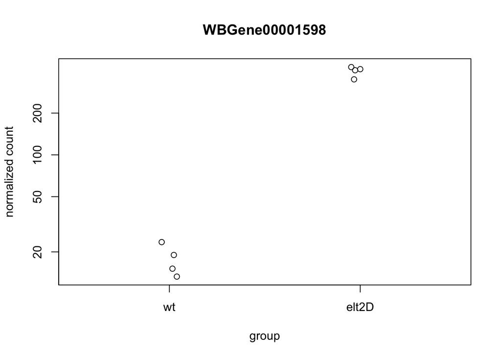

```r
plotCounts(dds, gene = "WBGene00001598")
```

See if elt-2 is depleted It is depleted

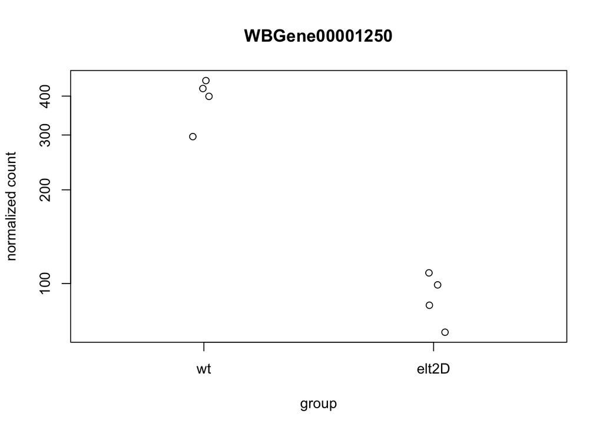

```r
plotCounts(dds, gene = "WBGene00001250")
```

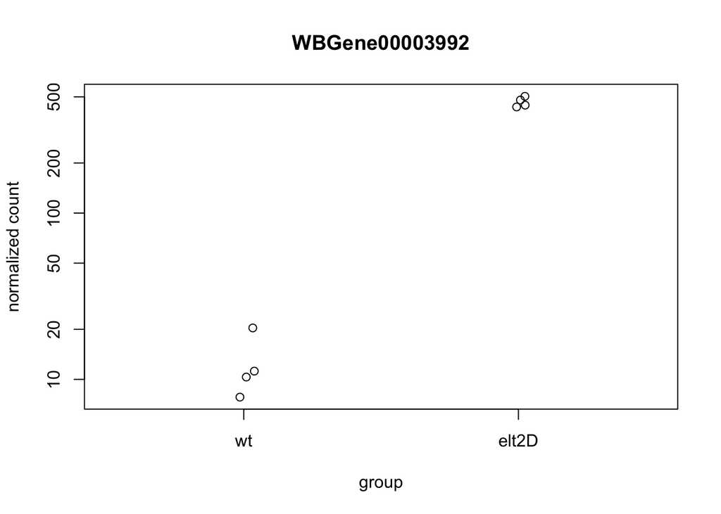

```r
plotCounts(dds, gene = "WBGene00003992")
```

see if egl-20 (ligand of Wnt pathway) is expressed Also is depleted

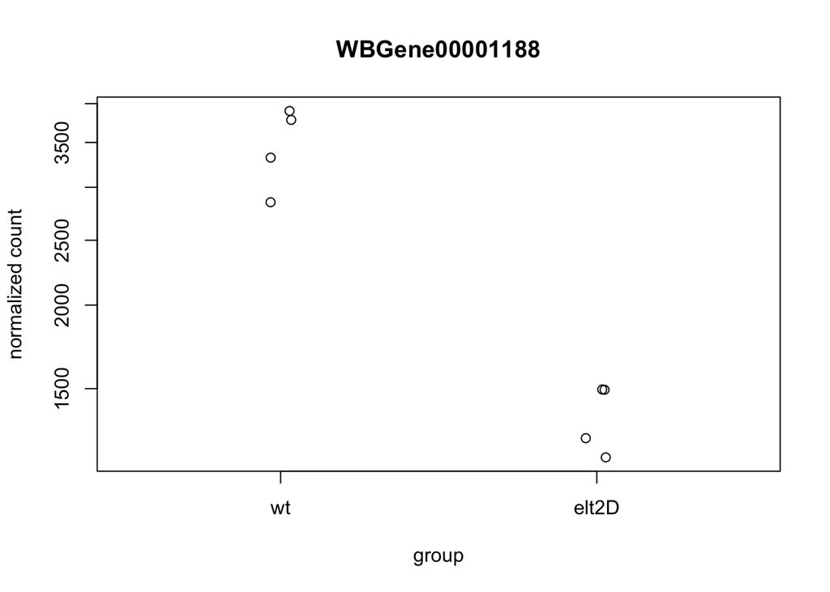

```r
plotCounts(dds, gene = "WBGene00001188")
```

Make an MA plot cus why not

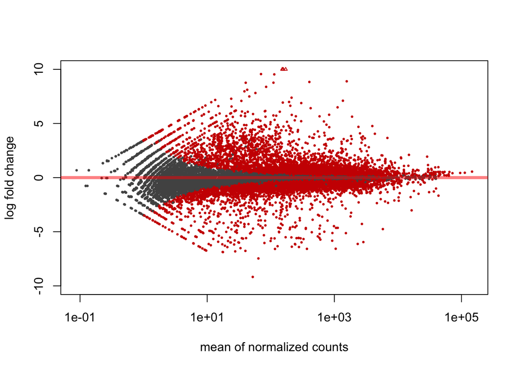

```r
plotMA(res, ylim = c(-10, 10))
```

Reformat for BETA

```r
betaDE <- data.frame(WBGeneID = rownames(res.df), lfc = res.df$log2FoldChange, q = res.df$padj)

write.table(betaDE, file = "./200218_L1_wt_vs_elt2D_results_BETA.tsv", sep = "\t", col.names = FALSE, row.names = FALSE, quote = FALSE)
```

# Import ChIP-seq data

```r
peaks <- read.delim("./01_input/L1_1_L1_2.IDR_0.05.narrowPeak", header = FALSE, sep = "\t")
head(peaks)
```

```
##     V1     V2     V3 V4   V5 V6       V7 V8 V9 V10      V11      V12
## 1 chrI   3689   4222  .  691  . 122.2085 -1 -1 265 1.003958 1.665635
## 2 chrI  11042  11533  .  656  . 114.2797 -1 -1 246 0.918801 1.580895
## 3 chrI  16768  17247  . 1000  . 161.8240 -1 -1 238 1.833459 2.488060
## 4 chrI 461492 461956  . 1000  . 240.3602 -1 -1 232 3.060893 3.689148
## 5 chrI 518137 518818  . 1000  . 279.4649 -1 -1 239 3.699794 4.270008
## 6 chrI 535202 535747  .  577  . 120.4394 -1 -1 273 0.743087 1.389755
##      V13    V14       V15 V16    V17    V18       V19 V20
## 1   3758   4222  50.40048 232   3689   4149  71.80800 230
## 2  11042  11506  48.29703 232  11073  11533  65.98264 230
## 3  16783  17247  88.13316 232  16768  17228  73.69081 230
## 4 461492 461956 128.87864 232 461495 461955 111.48154 230
## 5 518153 518818 135.53485 232 518137 518805 143.93004 230
## 6 535202 535666  73.45399 232 535287 535747  46.98543 230
```

```r
peaks_subset <- data.frame(chrom = peaks$V1, start = peaks$V2, end = peaks$V3, name = peaks$V4, score = peaks$V5, strand = peaks$V6)

write.table(peaks_subset, file = "200218_L1_ELT2_ChIP_Peaks_BETA.tsv", sep = "\t", col.names = FALSE, row.names = FALSE, quote = FALSE)
```